# Chap3. Graphics with ggplot2

#### geom_functions_my turn4

1. What geom would you use to draw a line chart? A boxplot? A histogram? An area chart?  
   line chart: geom_line(), boxplot: geom_boxplot(), histogram: geom_histogram(), area chart: geom_area()

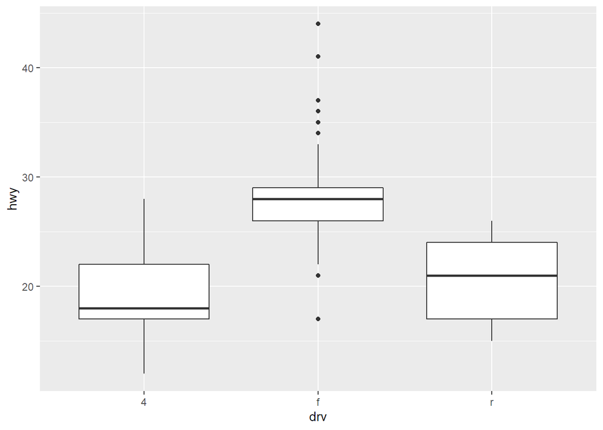

```r
mpg %>%
  ggplot()+
  geom_boxplot(aes(x=drv, y=hwy))
```

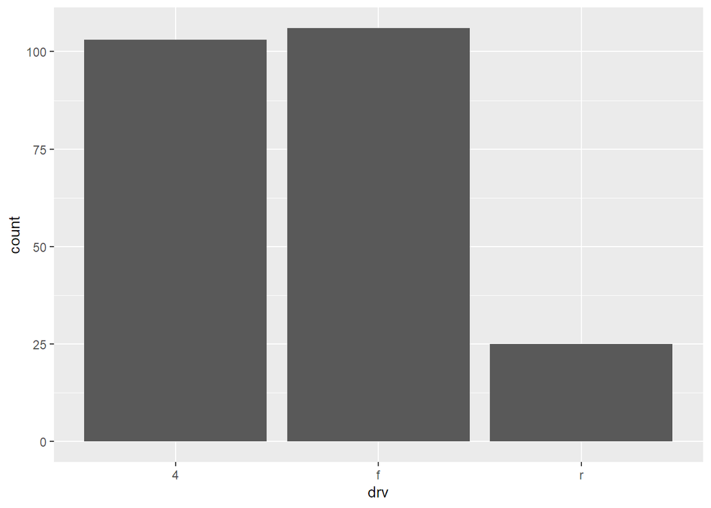

```r
mpg %>%
  ggplot()+
  geom_histogram(aes(x=drv), stat="count" )
```

2. **Run this code in your head and predict what the output will look like. Then, run the code in R and check your predictions.**

   ggplot()에 colour 또한 지정해주었으므로 point와 line 모두 drv범주에 따라 색깔을 나누고 se=FALSE를 설정하였기 때문에 standard error은 나타나지 않는다.

```r
ggplot(data=mpg, mapping=aes(x=displ,y=hwy,colour=drv))+
  geom_point() + geom_smooth(se=FALSE)
```

[output not shown]

3. **What does show.legend = FALSE do? What happens if you remove it? Why do you think I used it earlier in the chapter?**

   show.legend=FALSE -> coloring에 대한 legend를 뺀다

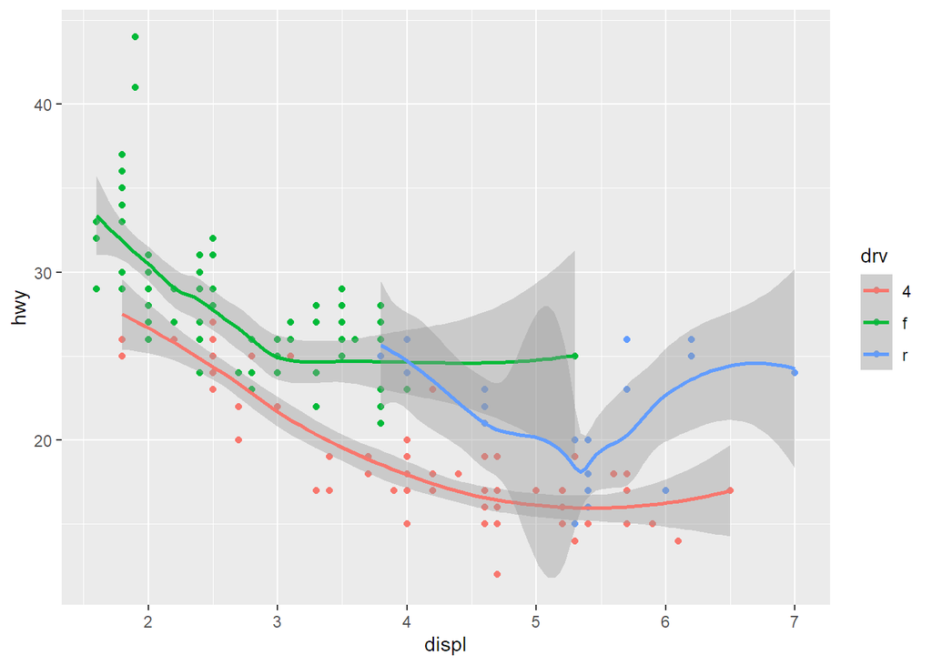

```r
ggplot(data=mpg, mapping=aes(x=displ,y=hwy,colour=drv),
       show.legend=FALSE)+
  geom_point() + geom_smooth()
```

5. **What does the se argument to geom_smooth() do?**

   옵션 se=standard error를 의미 -> se=FALSE : standard error를 제외하고 graph를 그린다.

```r
ggplot(data=mpg, mapping=aes(x=displ,y=hwy,colour=drv),
       show.legend=FALSE)+
  geom_point() + geom_smooth(se=FALSE)
```

[output not shown]

6. Will these two graphs look different? Why/why not?

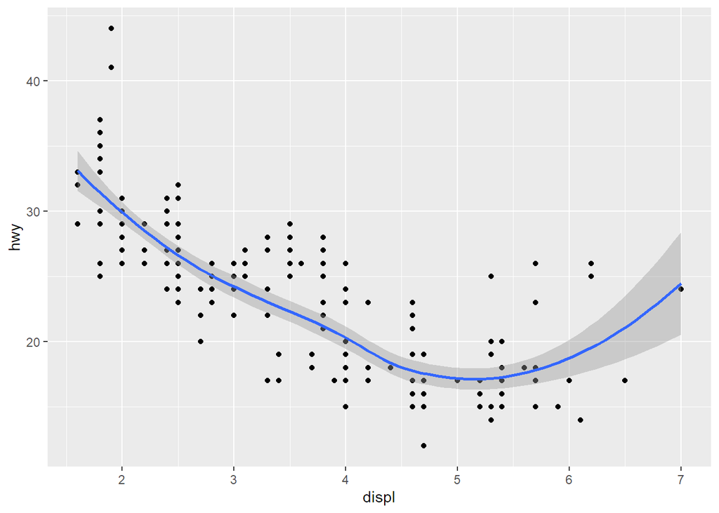

```r
ggplot(data=mpg, mapping=aes(x=displ, y=hwy)) +
  geom_point() + geom_smooth()
```

```r
ggplot() +
  geom_point(data=mpg, mapping = aes(x=displ, y=hwy)) +
  geom_smooth()
```

[output not shown]

7. Use variables displ, hwy, drv and recreate following plots.  
   7-1

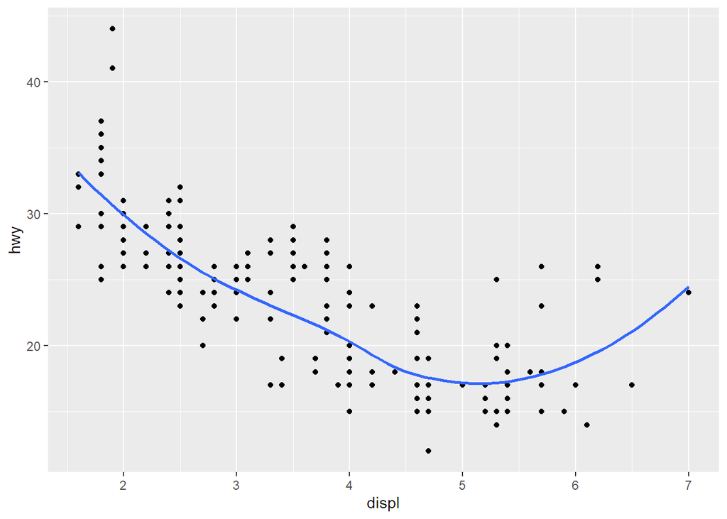

```r
mpg %>%
  ggplot(mapping=aes(x=displ, y=hwy)) +
  geom_point() + geom_smooth(se=FALSE)
```

- geom을 이용하여 산점도와 x축과 y축의 관계를 나타낸 그래프를 함께 볼 수 있다.  
  이에 따르면, 엔진배기량과 고속도로 주행 거리는 음의 상관관계를 보임을 알 수 있다.

7-2

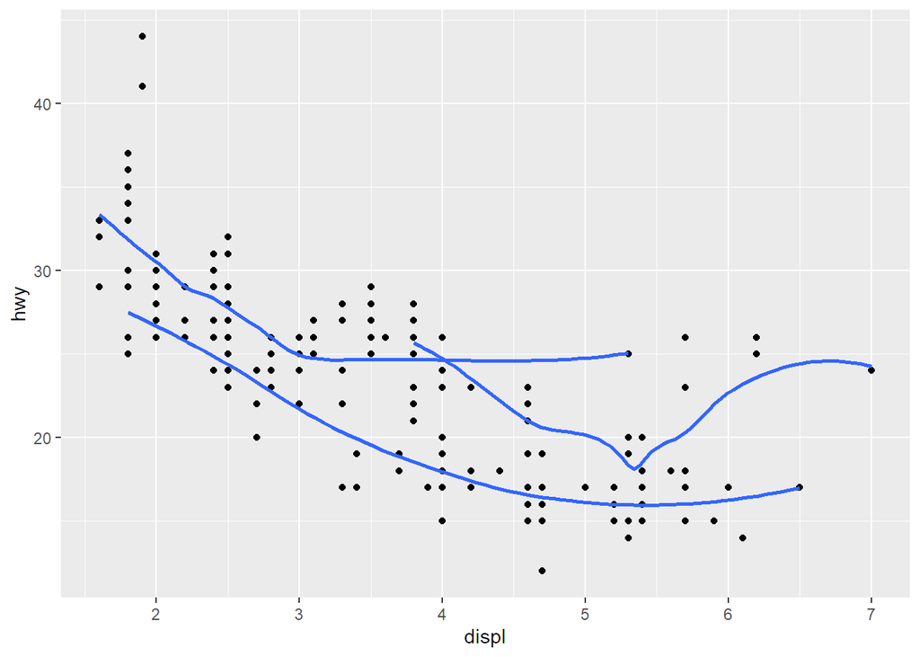

```r
mpg %>%
  ggplot(mapping=aes(x=displ, y=hwy)) +
  geom_point() + geom_smooth(aes(group=drv),se=FALSE)
```

7-3

```r
mpg %>%
  ggplot(mapping=aes(x=displ, y=hwy)) +
  geom_point(aes(colour=drv)) + geom_smooth(aes(colour=drv),se=FALSE)
```

[output not shown]

- 색깔을 열차종류 변수로 지정하여 어떤 열차의 산점도와 그래프인지 알 수 있다.  
  이를 통해 f열차는 엔진배기량이 작고 r열차는 엔진배기량이 크고  
  4열차는 다양한 엔진배기량을 사용한다는 것을 추가적으로 알 수 있다.

7-4

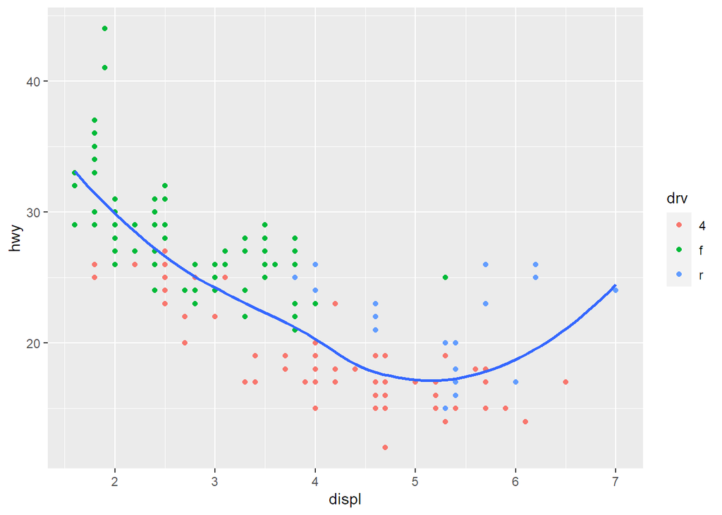

```r
mpg %>%
  ggplot(mapping=aes(x=displ, y=hwy)) +
  geom_point(aes(colour=drv)) + geom_smooth(se=FALSE)
```

- 열차 종류에 따른 엔진배기량과 주행거리의 분포를 알 수 있고  
  전반적으로 엔진배기량과 주행거리는 음의 관계에 있음을 알 수 있다.

7-5

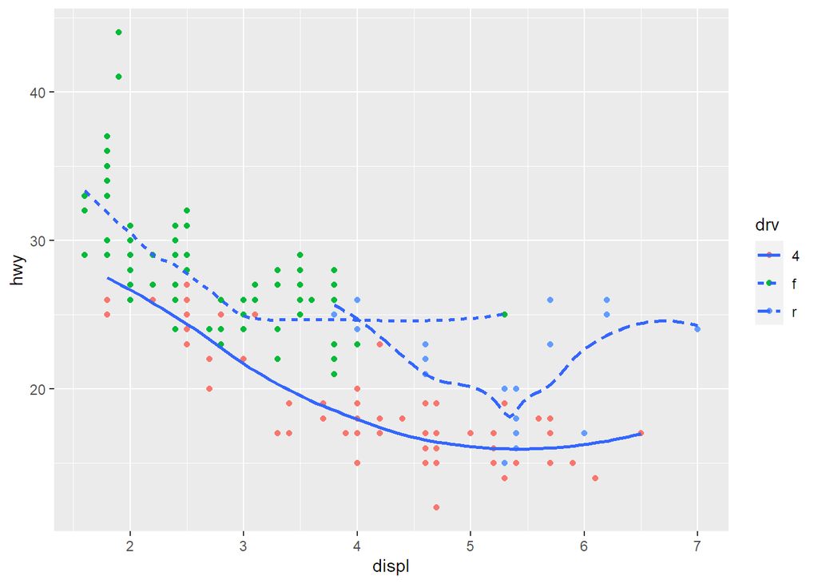

```r
mpg %>%
  ggplot(mapping=aes(x=displ, y=hwy)) +
  geom_point(aes(colour=drv)) + geom_smooth(aes(linetype=drv),se=FALSE)
```

- linetype을 열차종류 변수로 지정하여 각 종류마다 다른 선모양으로 구분할 수 있다.

7-6

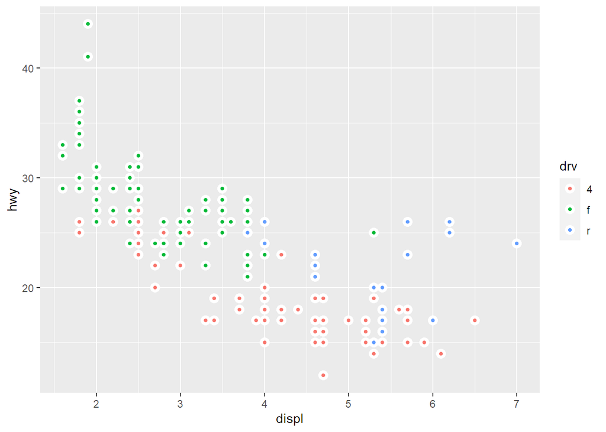

```r
mpg %>%
  ggplot(mapping=aes(x=displ, y=hwy)) +
  geom_point(mapping=aes(fill=drv), shape=21, colour="white", stroke=2)
```

- shape을 지정하면, 점의 모양을 조정할 수 있고 이때, stroke은 점의 테두리 두께를 의미한다.  
  이에 따라 점의 테투리 색은 colour로 점 안의 색은 fill로 지정해준다.

### 5. Statistical transformations

```r
library(tidyverse)
diamonds
```

```
## # A tibble: 53,940 x 10
##    carat cut       color clarity depth table price     x     y     z
##    <dbl> <ord>     <ord> <ord>   <dbl> <dbl> <int> <dbl> <dbl> <dbl>
##  1 0.23  Ideal     E     SI2      61.5    55   326  3.95  3.98  2.43
##  2 0.21  Premium   E     SI1      59.8    61   326  3.89  3.84  2.31
##  3 0.23  Good      E     VS1      56.9    65   327  4.05  4.07  2.31
##  4 0.290 Premium   I     VS2      62.4    58   334  4.2   4.23  2.63
##  5 0.31  Good      J     SI2      63.3    58   335  4.34  4.35  2.75
##  6 0.24  Very Good J     VVS2     62.8    57   336  3.94  3.96  2.48
##  7 0.24  Very Good I     VVS1     62.3    57   336  3.95  3.98  2.47
##  8 0.26  Very Good H     SI1      61.9    55   337  4.07  4.11  2.53
##  9 0.22  Fair      E     VS2      65.1    61   337  3.87  3.78  2.49
## 10 0.23  Very Good H     VS1      59.4    61   338  4     4.05  2.39
## # ... with 53,930 more rows
```

geom_bar/ default값이 stat=“count”이므로 stat_count()와 동일하게 사용된다.

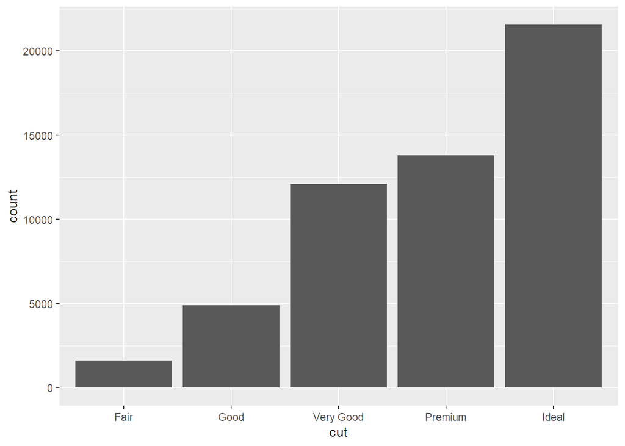

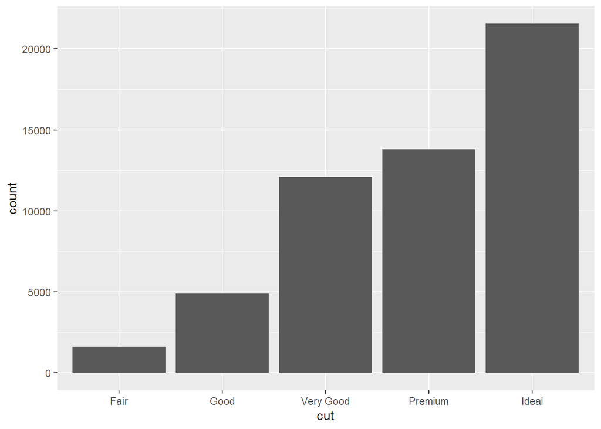

stat_summary - 작년 중간고사에 출제  
=> 각 x값에 대한 y값을 summarise할 때 유용하게 사용된다  
=> fun.ymin, fun.ymax, fun.y를 이용하여 y를 summarise할 수 있고 colour,shape 등을 조절할 수 있다.  
geom=“point”, geom=“line” 등을 통해 어떻게 나타낼지도 조정할 수 있다.

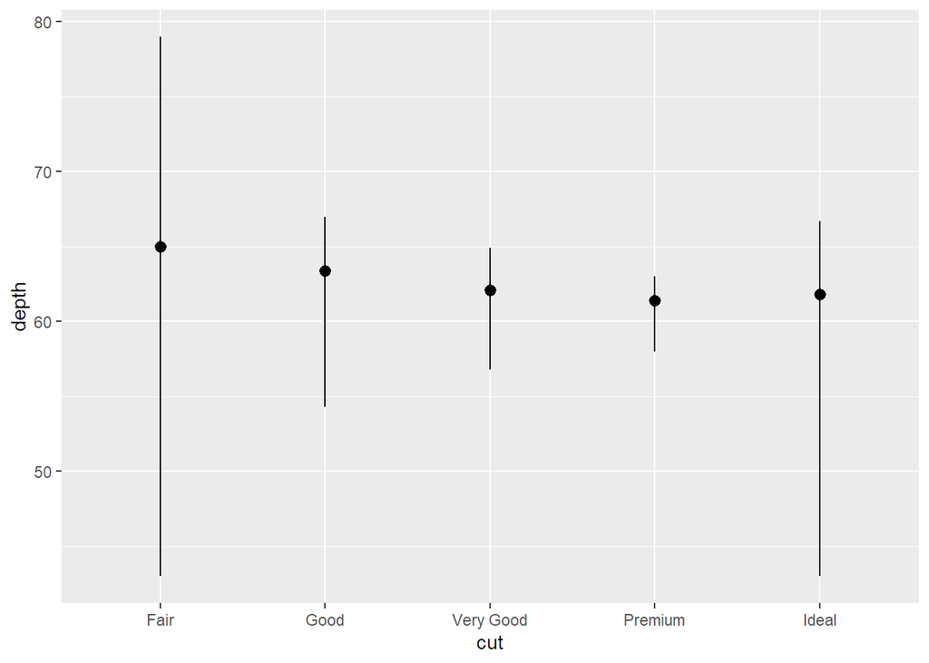

```r
ggplot(data=diamonds) +
  stat_summary(
    mapping = aes(x=cut,y=depth),
    fun.ymin = min,
    fun.ymax = max,
    fun.y = median
  )
```

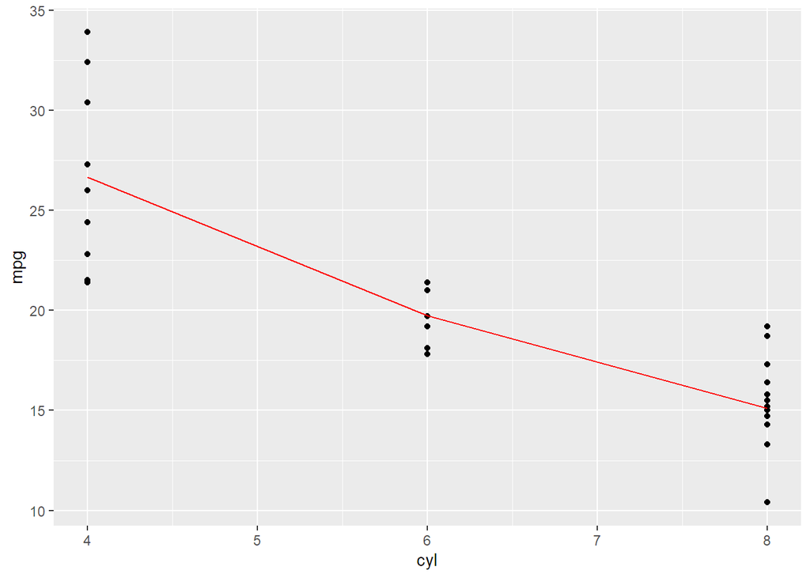

```r
d= ggplot(mtcars, aes(cyl,mpg)) + geom_point()
d + stat_summary(fun.y="mean", colour="red", shape=3,
                 geom="line")
```

#### Statistical transformations_my turn5

1. **What variables does stat_smooth() compute? What parameters control its behaviour?**

   stat_smooth()는 y의 예측값과 신뢰구간을 알 수 있다.

```r
?stat_smooth()
ggplot(mtcars, aes(disp,mpg)) +
  geom_point(aes(colour=cyl)) +
  stat_smooth()
```

[output not shown]

2. Bar charts for proportion
- 양쪽에 .. 넣는 것 : count를 의미
- group=1 지정을 함으로써 전체 count에서 각 범주별 count에 대한 비율을 알 수 있다.  
  -> 1을 전체로 보고 각 count의 비율을 나타내는 것

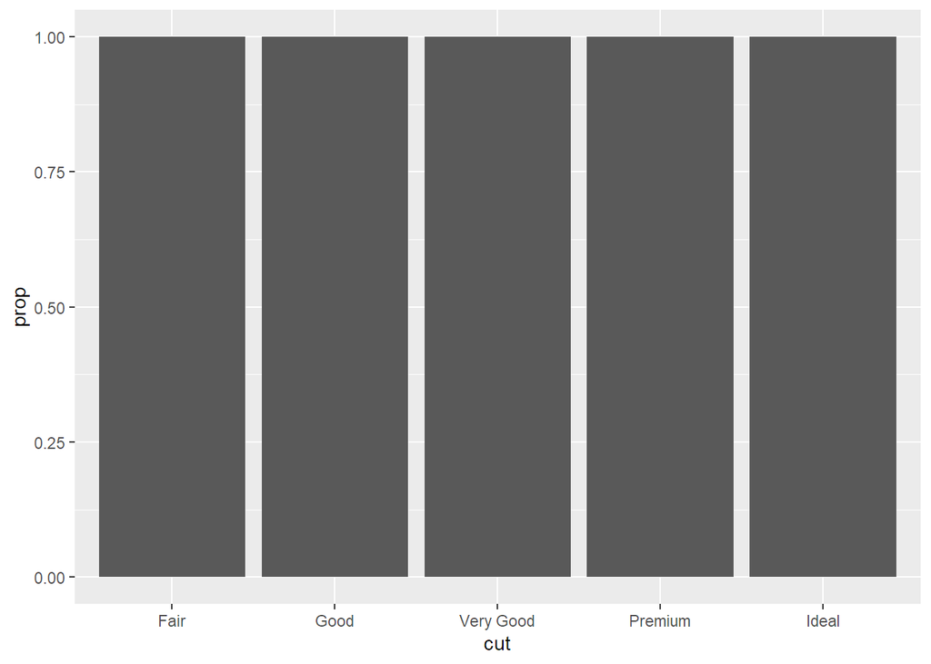

```r
ggplot(data=diamonds) +
  geom_bar(mapping = aes(x=cut, y=..prop..))
```

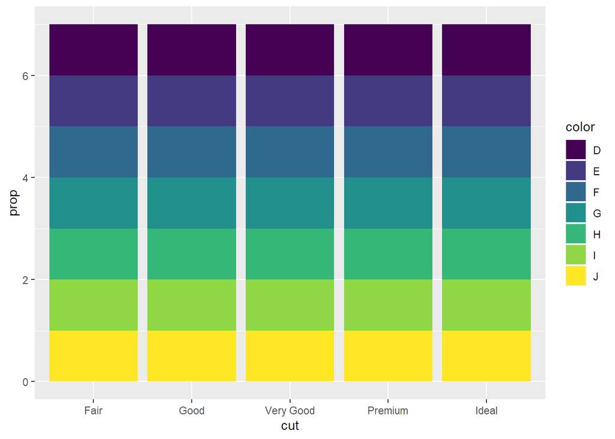

```r
ggplot(data=diamonds) +
  geom_bar(mapping = aes(x=cut, fill=color, y=..prop..))
```

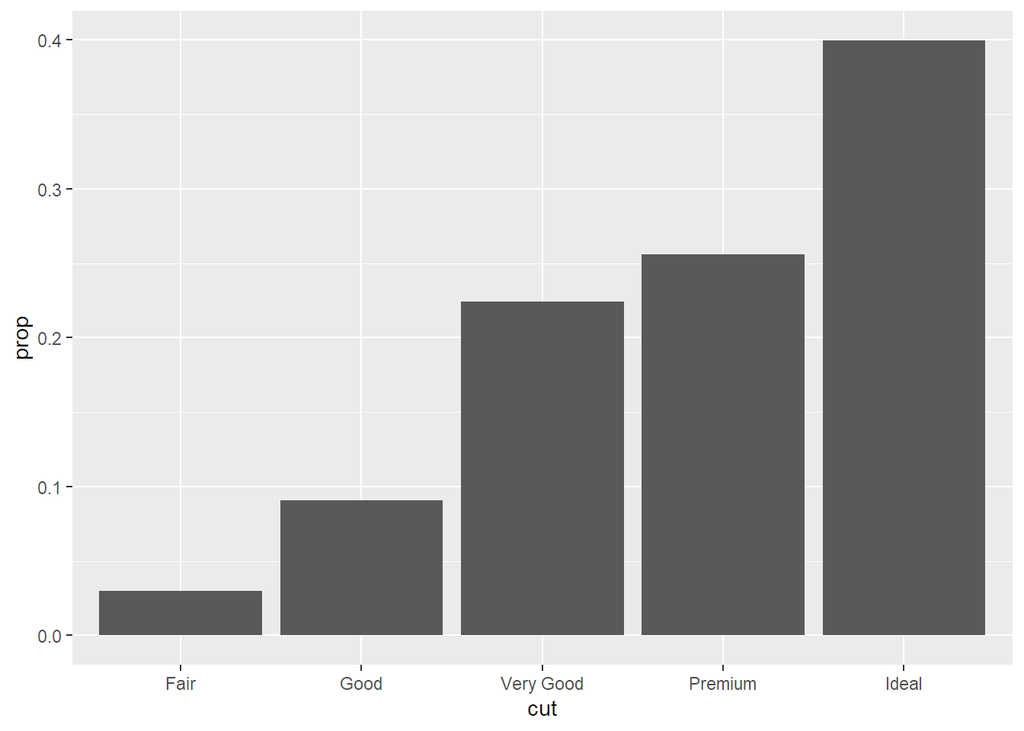

```r
ggplot(data=diamonds) +
  geom_bar(mapping = aes(x=cut, y=..prop.., group=1))
```

3. With the fill aesthetic, the heights of the bars need to be normalized.
- 각 color별 percent 또한 알기 위해 정규화한다.

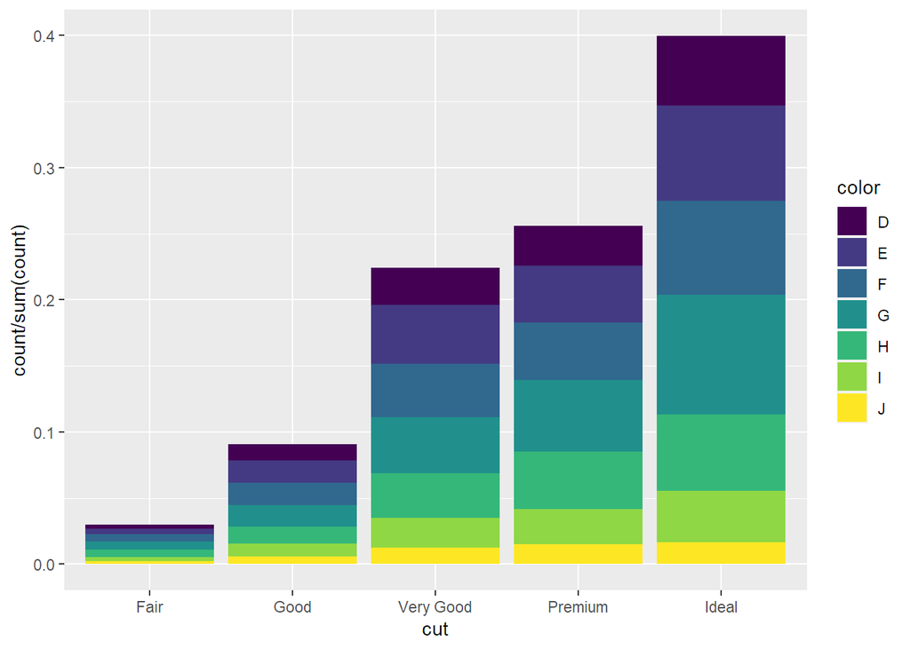

```r
ggplot(data=diamonds)+
  geom_bar(aes(x=cut,y=..count../sum(..count..),fill=color))
```

### 6. Position adjustments

geom_bar의 colour-> boundary 색깔, fill-> bar자체의 색깔  
x와 다른 변수 입력 시, 범주별 색깔 구분하여 count

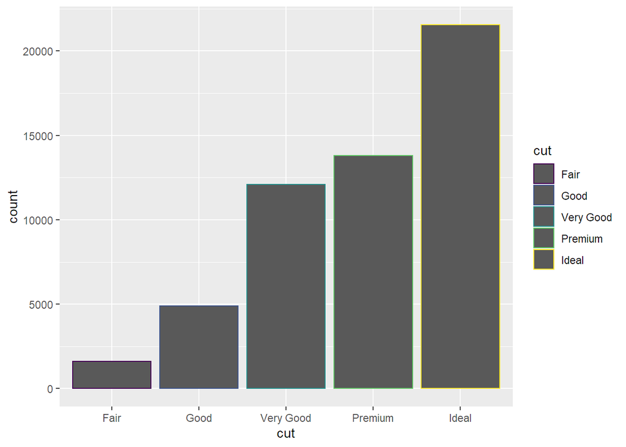

```r
ggplot(data=diamonds) +
   geom_bar(mapping=aes(x=cut, colour=cut))
```

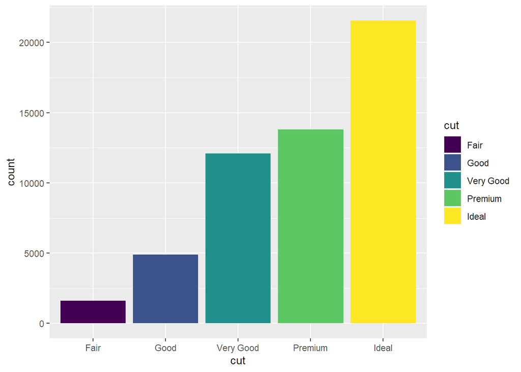

```r
ggplot(data=diamonds) +
   geom_bar(mapping=aes(x=cut, fill=cut))
```

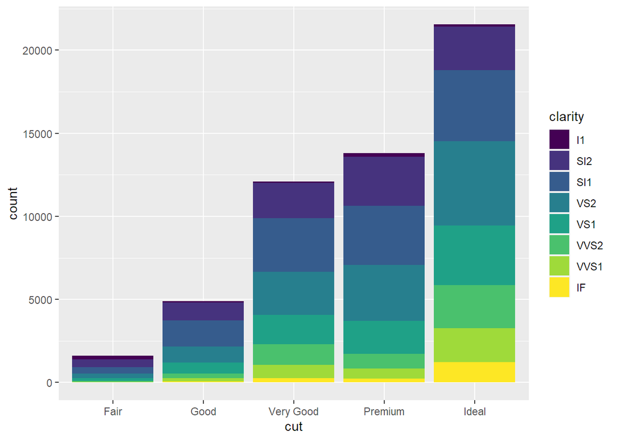

```r
ggplot(data=diamonds) +
   geom_bar(mapping=aes(x=cut, fill=clarity))
```

alpha : 투명도  
fill= NA 색깔 없음 - text 채워넣어야 할때 필요

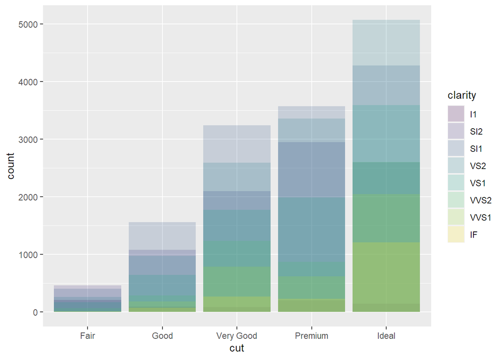

```r
ggplot(data = diamonds,
       mapping = aes(x = cut,fill = clarity)) +
  geom_bar(alpha = 1/5, position = "identity")
```

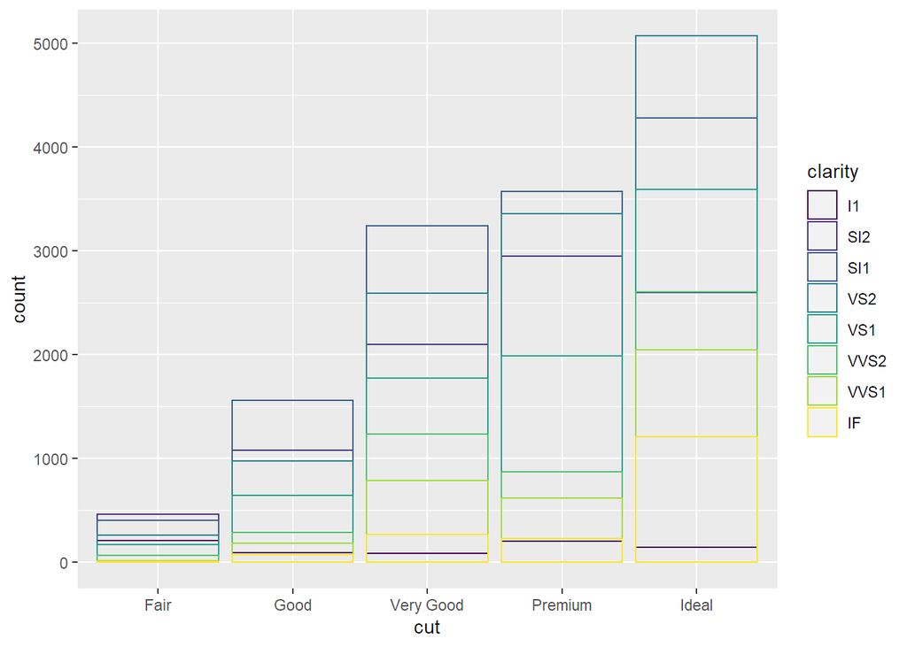

```r
ggplot(data = diamonds,
mapping = aes(x = cut, colour = clarity)) +
geom_bar(fill = NA, position = "identity")
```

position  
=identity : geom_bar에만 해당하는 옵션으로 겹쳐서 나온다.  
=fill : (상대적인 비교가 필요할때) 100%라고 봤을 대 각 그룹에서 퍼센트 어떠케 차지하느냐  
=dodge : 그룹별 각각의 count를 옆으로 bar graph 나열  
=jitter : 비슷한 점들 겹쳐서 안보이는 것들을 흩으려놓고 몇개정도 있는지 보기 위한 것

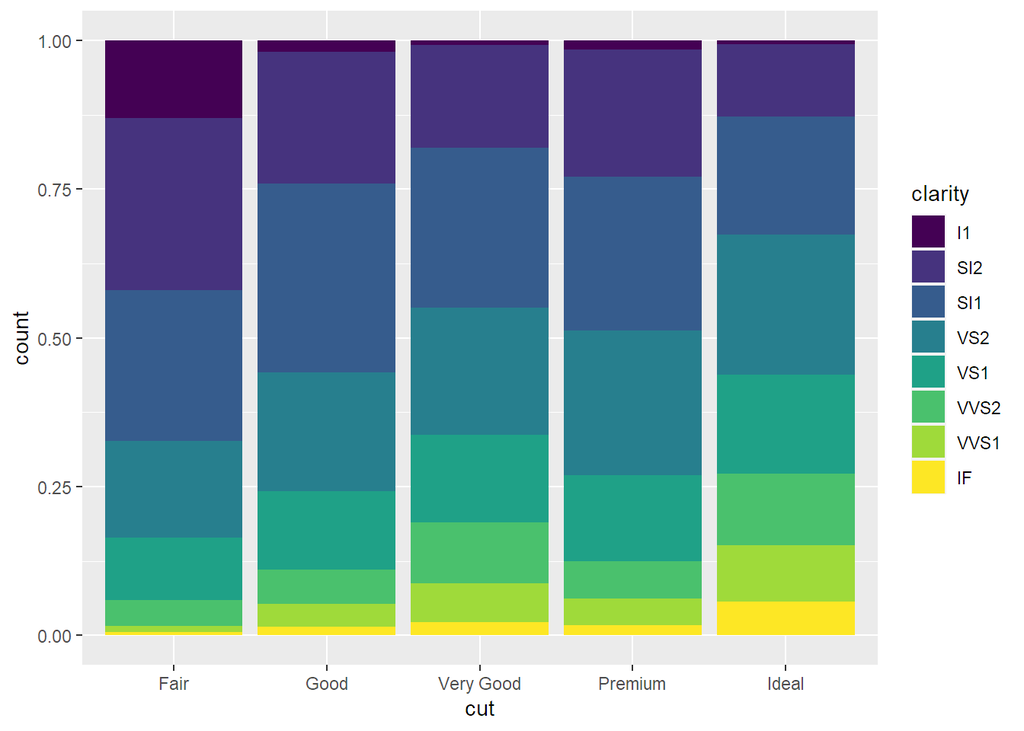

```r
ggplot(data = diamonds) +
  geom_bar(mapping = aes(x = cut, fill = clarity),
           position = "fill")
```

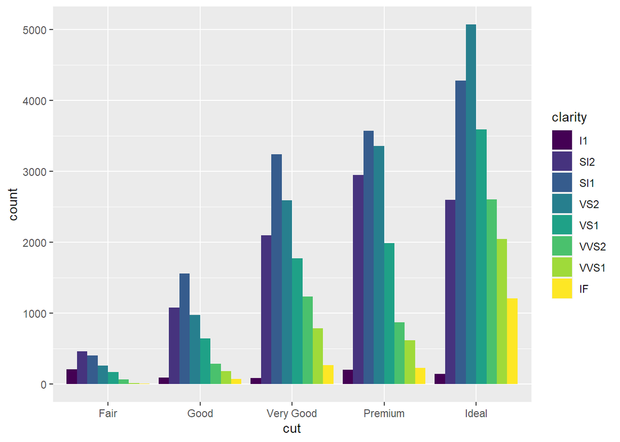

```r
ggplot(data = diamonds) +
  geom_bar(mapping = aes(x = cut, fill = clarity),
           position = "dodge")
```

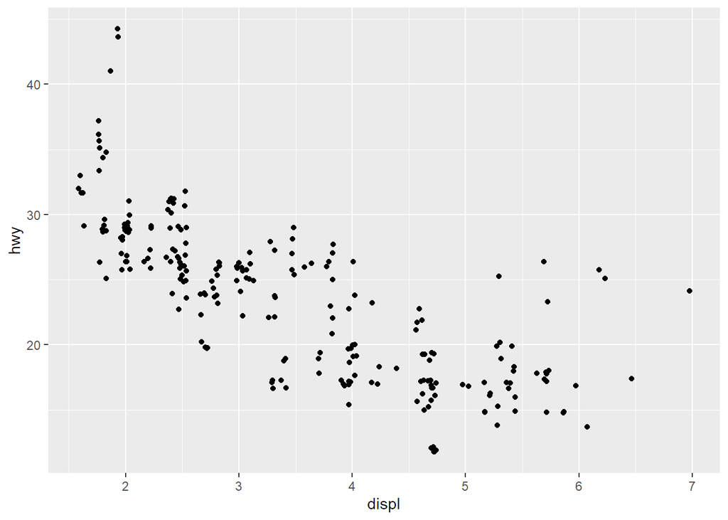

```r
ggplot(data = mpg) +
  geom_point(mapping = aes(x = displ, y = hwy),
             position = "jitter")
```

#### Position adjustments_my turn6

**What’s the default position adjustment for geom_boxplot()? Create a visualization of the mpg dataset that demonstrates it.**

position 미지정시, 각 group별 boxplot을 따로 따로 그린다.

position=“identity” -> 각 group별 상자그림 겹쳐져서 확인 - drv별 전체 분포를 알기 쉽다.

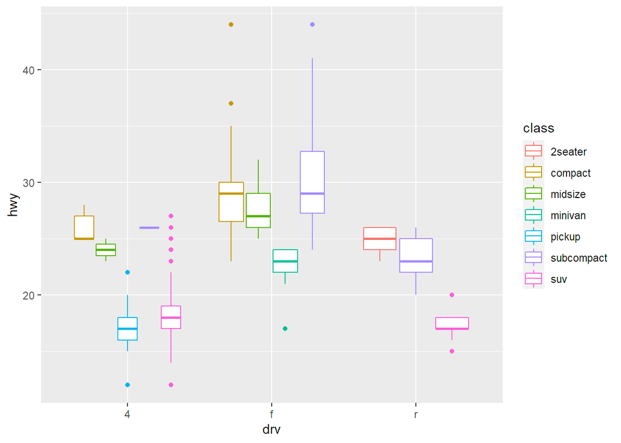

```r
ggplot(data=mpg, aes(x=drv, y=hwy, colour=class)) +
   geom_boxplot()
```

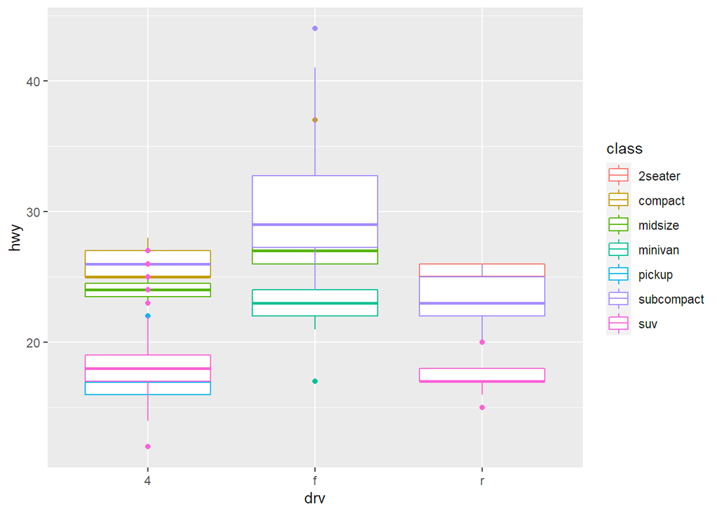

```r
ggplot(data=mpg, aes(x=drv, y=hwy, colour=class)) +
   geom_boxplot(position = "identity")
```

### 7. Coordinate systems

coord_flip() : x,y축 뒤집어 준다.

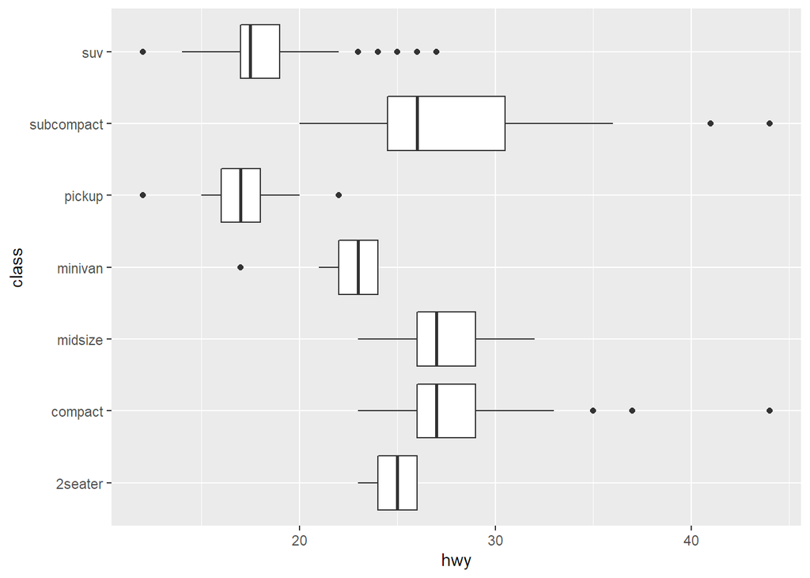

```r
ggplot(data=mpg, aes(x=class, y=hwy)) +
   geom_boxplot()+ coord_flip()
```

coord_quickmap : 그림을 알맞게 조정

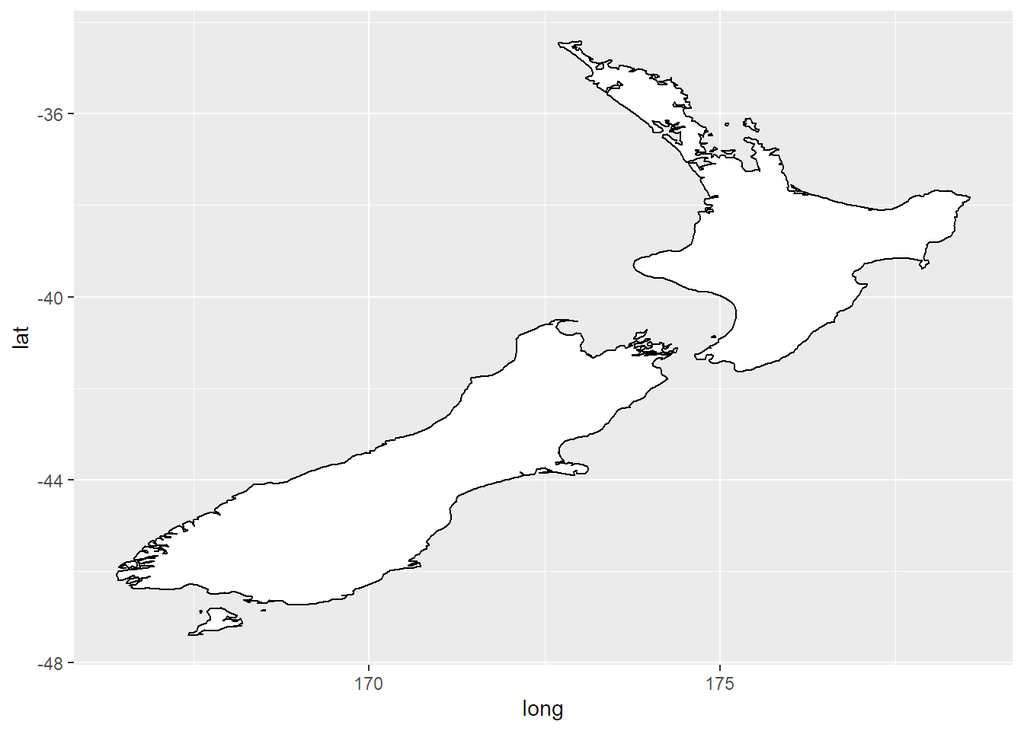

```r
library(maps)
nz = map_data("nz")
ggplot(nz, aes(long, lat, group=group)) +
  geom_polygon(fill="white", colour="black")
```

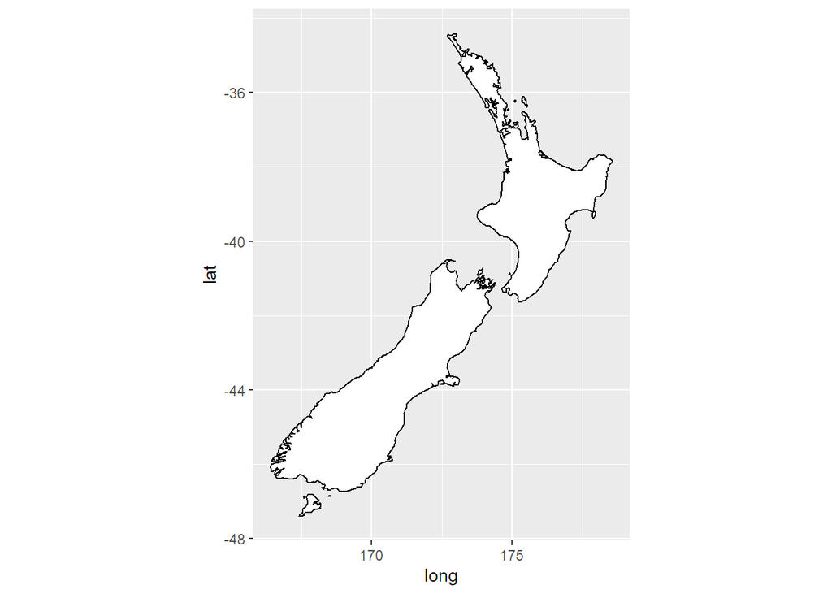

```r
ggplot(nz, aes(long, lat, group=group)) +
  geom_polygon(fill="white", colour="black") +
  coord_quickmap()
```

coord_polar : 원형으로 퍼지는 형태

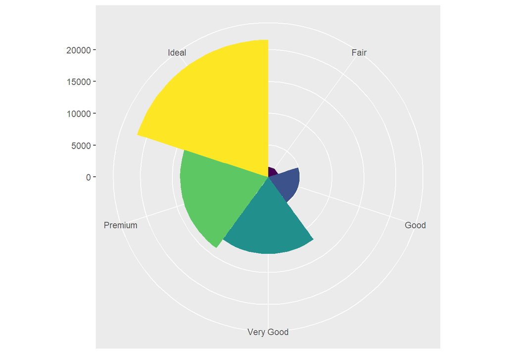

```r
bar = ggplot(data=diamonds) +
  geom_bar(mapping= aes(x=cut, fill=cut), show.legend=FALSE, width=1) +
  theme(aspect.ratio=1) + labs(x=NULL, y=NULL)
bar + coord_polar()
```

#### Coordinate systems_my turn7

1. Turn a stacked bar chart into a pie chart using coord_polar().
- 데이터에 따라 무슨 형태의 그림으로 보여줄지 생각해볼 필요 -> pie-chart형태
- factor(1) : drv에 대해서만 그래프 그리도록 한다.

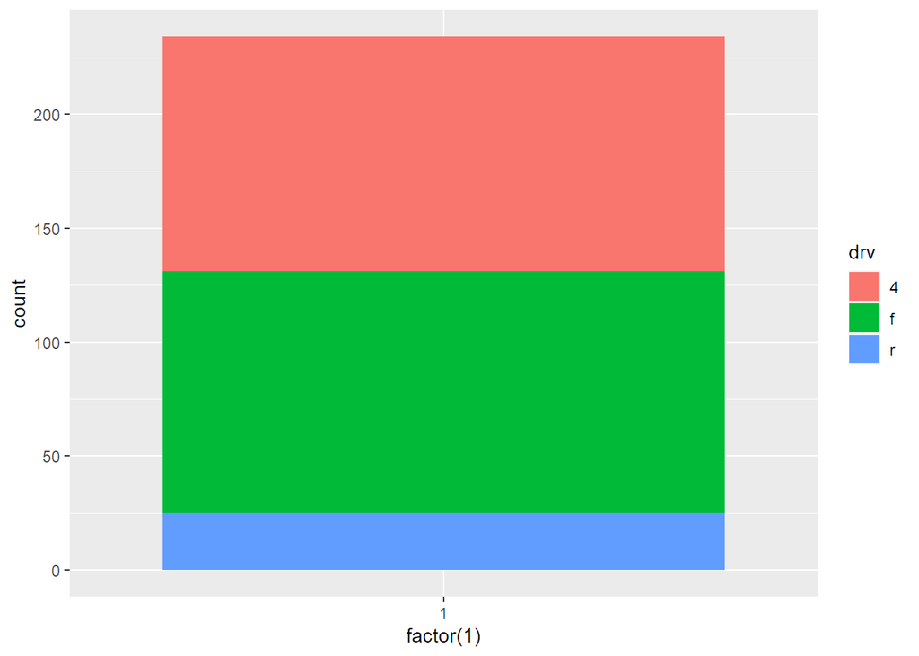

```r
ggplot(mpg, aes(x=factor(1), fill=drv)) +
  geom_bar()
```

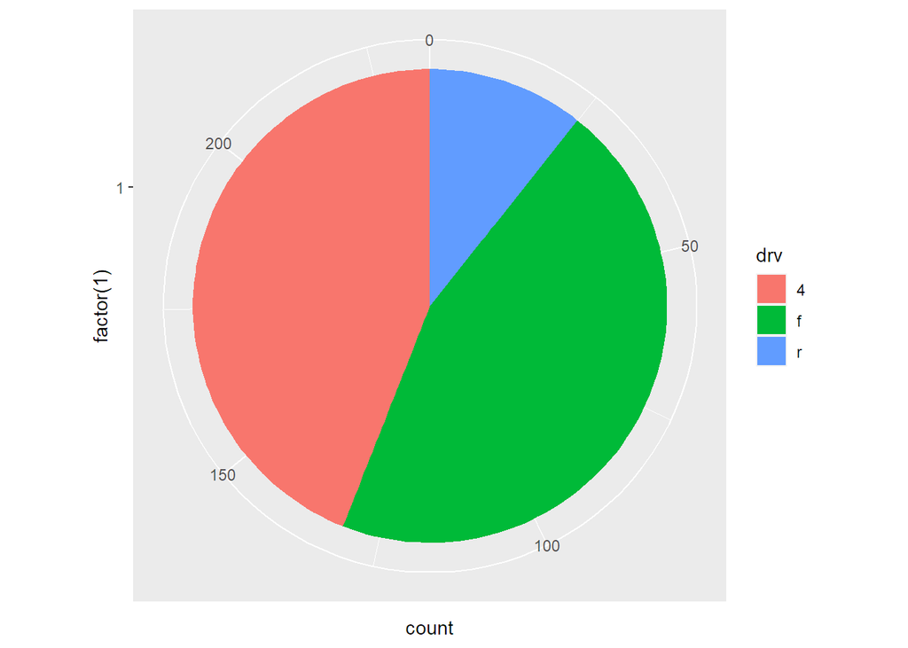

```r
ggplot(mpg, aes(x=factor(1), fill=drv)) +
  geom_bar(width=1) + coord_polar(theta='y')
```

- theta=‘y’ 지정하지 않을시, bulls-eye chart가 생성되나 이 그림은 안 그리는 것이 좋다.

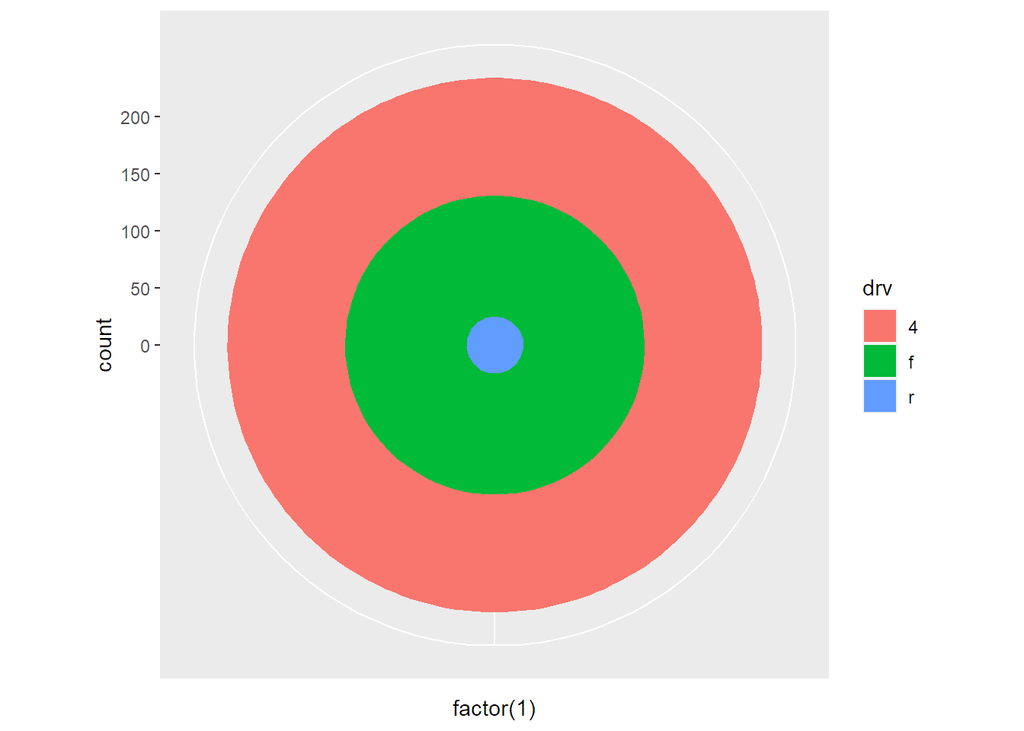

```r
ggplot(mpg, aes(x=factor(1), fill=drv)) +
  geom_bar(width=1) + coord_polar()
```

2. What does labs() do? Read the documentation.

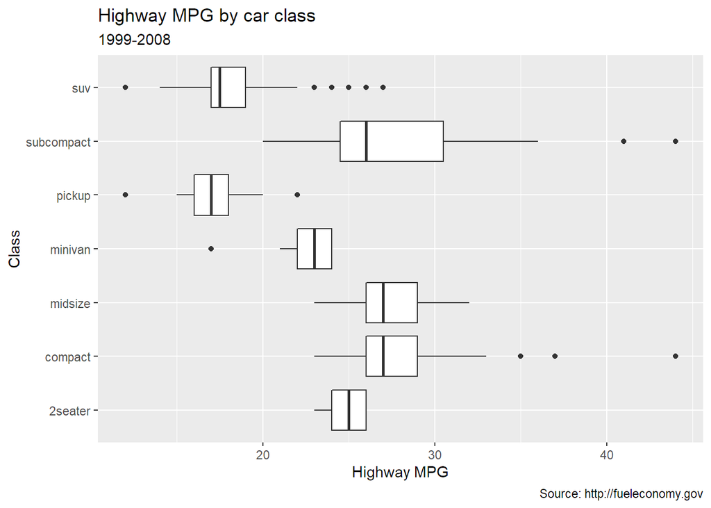

```r
ggplot(data=mpg, mapping=aes(x=class, y=hwy)) +
  geom_boxplot() + coord_flip() +
  labs(y="Highway MPG", #ylab
       x="Class", #xlab
       title="Highway MPG by car class", #ggtitle
       subtitle = "1999-2008",
       caption="Source: http://fueleconomy.gov")
```

### [ggplot gallery](https://www.r-graph-gallery.com/)

```r
install.packages("igraph")
library(igraph)

# Create data
data <- matrix(sample(0:1, 400, replace=TRUE, prob=c(0.8,0.2)), nrow=20)
network <- graph_from_adjacency_matrix(data , mode='undirected', diag=F )

# When ploting, we can use different layouts:
par(mfrow=c(2,2), mar=c(1,1,1,1))
plot(network, layout=layout.sphere, main="sphere")
plot(network, layout=layout.circle, main="circle")
plot(network, layout=layout.random, main="random")
plot(network, layout=layout.fruchterman.reingold, main="fruchterman.reingold")


library(gapminder)

# Charge libraries:
library(ggplot2)
library(gganimate)

# Make a ggplot, but add frame=year: one image per year
ggplot(gapminder, aes(gdpPercap, lifeExp, size = pop, color = continent)) +
  geom_point() +
  scale_x_log10() +
  theme_bw() +
  # gganimate specific bits:
  labs(title = 'Year: {frame_time}', x = 'GDP per capita', y = 'life expectancy') +
  transition_time(year) +
  ease_aes('linear')

# Save at gif:왜error가 나타날까
anim_save("271-ggplot2-animated-gif-chart-with-gganimate1.gif")
```